# Individual Homework

Your name goes here

2025-09-30

# 1 Grading visualisations

Using the Data Visualisation checklist (under session1 files), please ‘grade’ Figure 3 of the [JPMorgan Chase Institute on Year-over-year percent change in credit card spending by essential category](https://www.jpmorganchase.com/institute/all-topics/financial-health-wealth-creation/initial-household-spending-response-to-covid-19-evidence-from-credit-card-transactions). If you wanted the actual paper on which this publication was based, you can [find it here](https://bfi.uchicago.edu/wp-content/uploads/BFI_WP_202082.pdf).

## 1.1 Guideline

| Dimension | Score | Comments |
| --- | --- | --- |
| G1 | 1 | descriptive title but misalligned |
| G2 | 2 | well done, clear |
| G3 | 2 | titles are bigger, notes are the smallest |
| G4 | 2 | only horizontal |
| G5 | 1 | only the axes are labeled directly but even they are hard to differentiate from one another, understanding is hard |
| G6 | 2 | labels are ok, but I suggest using only 3 letters of each month to make it more comprehensive |
| **TOTAL** | 10 | Generally, the text is ok |

## 1.2 Arrangement

| Dimension | Score | Comments |
| --- | --- | --- |
| A1 | 2 | accurate |
| A2 | 2 | ordered correctly |
| A3 | 2 | distance is equal |
| A4 | 2 | two dimensions |
| A5 | 2 | no decoration |
| **TOTAL** | 10 | followed the principles |

## 1.3 Colour

| Dimension | Score | Comments |
| --- | --- | --- |
| C1 | n/a | not concerning |
| C2 | 0 | groceries should be highlighted |
| C3 | 0 | print then dump |
| C4 | 0 | colorblind combinations |
| C5 | 2 | good contrast |
| **TOTAL** | 2 | few good shots was available in this case, none really taken |

## 1.4 Lines

| Dimension | Score | Comments |
| --- | --- | --- |
| L1 | 2 | gridlines are useful, quiet |
| L2 | 2 | good embedding |
| L3 | 2 | even though marks are present, they seems necessary |
| L4 | 2 | simple axes |
| **TOTAL** | 8 | well done with the lines |

## 1.5 Overall

| Dimension | Score | Comments |
| --- | --- | --- |
| O1 | 1 | not really highlighting |
| O2 | 2 | appropriate chart type |
| O3 | 2 | precise and simple |
| O4 | 1 | mostly yes, but nothing highlights the “groceries” part |
| **TOTAL** | 6 | Generally impressive but a make-up could help it |

# 2 Prepare the worst possible visualisation

```r
# Load the gapminder package
# Load the skimr package
# scales package to help with axis formatting
# Load the tidyverse package
library(gapminder)
library(tidyverse)
library(skimr)
library(scales)
library(RColorBrewer)
```

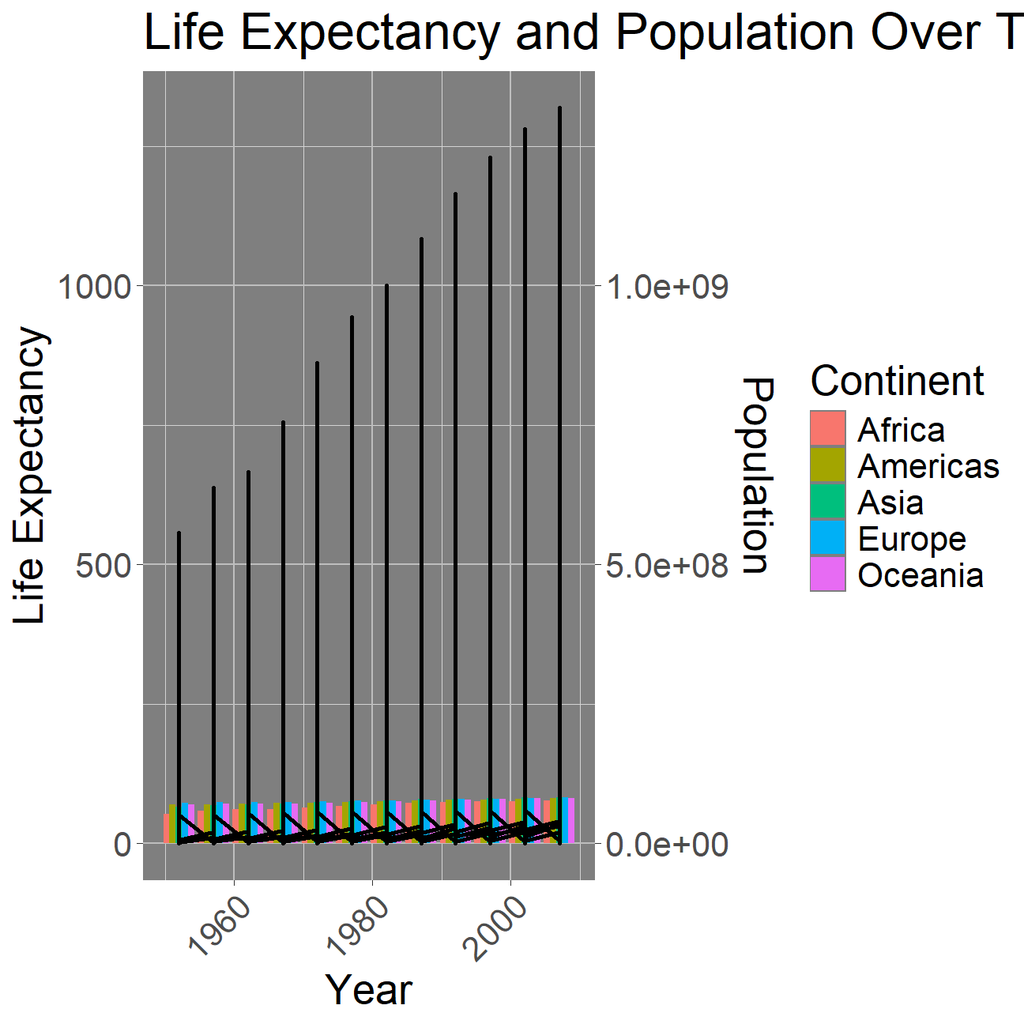

```r
# barchart plot gapminder, x axis is year, y axis is lifeExp, second y axis is population, color by continent, all text same size
ggplot(gapminder, aes(x = year, y = lifeExp, fill = continent)) +
  geom_bar(stat = "identity", position = "dodge") +
  geom_line(aes(y = pop / 1000000, group = continent), color = "black", size = 1) +
  scale_y_continuous(
    name = "Life Expectancy",
    sec.axis = sec_axis(~ . * 1000000, name = "Population")
  ) +
  labs(title = "Life Expectancy and Population Over Time by Continent",
       x = "Year",
       fill = "Continent") +
  theme_dark() +
  theme(
    text = element_text(size = 20),
    axis.text.x = element_text(angle = 45, hjust = 1),
    panel.grid.major = element_line(color = "grey", size = 0.5),
    panel.grid.minor = element_line(color = "lightgrey", size = 0.25)
  )
```

# 3 Rents in San Francsisco Bay Area 2000-2018

[Kate Pennington](https://www.katepennington.org/data) created a panel of historic Craigslist rents by scraping posts archived by the Wayback Machine. You can read more about her work here

[What impact does new housing have on rents, displacement, and gentrification in the surrounding neighborhood? Read our interview with economist Kate Pennington about her article, “Does Building New Housing Cause Displacement?:The Supply and Demand Effects of Construction in San Francisco.”](https://matrix.berkeley.edu/research-article/kate-pennington-on-gentrification-and-displacement-in-san-francisco/)

In our case, we have a clean(ish) dataset with about 200K rows that correspond to Craigslist listings for renting properties in the greater SF area. The data dictionary is as follows

| variable | class | description |
| --- | --- | --- |
| post_id | character | Unique ID |
| date | double | date |
| year | double | year |
| nhood | character | neighborhood |
| city | character | city |
| county | character | county |
| price | double | price in USD |
| beds | double | n of beds |
| baths | double | n of baths |
| sqft | double | square feet of rental |
| room_in_apt | double | room in apartment |
| address | character | address |
| lat | double | latitude |
| lon | double | longitude |
| title | character | title of listing |
| descr | character | description |
| details | character | additional details |

The dataset was used in a recent [tidyTuesday](https://github.com/rfordatascience/tidytuesday) project.

```r
# download directly off tidytuesdaygithub repo

rent <- readr::read_csv('https://raw.githubusercontent.com/rfordatascience/tidytuesday/master/data/2022/2022-07-05/rent.csv')
```

What are the variable types? Do they all correspond to what they really are? Which variables have most missing values?

Based on the tables, the location variables have the most missing values (longitude, latitude => addresses), but similarly does the description and details variable. Furthermore, a lot of records missing bathroom numbers, space in squarefeet and a few misses beds number as well.

The variable types seem to be correct, except for the date variable, which should be a date type instead of double. Year, beds, baths, room_in_apt are double instead of int and descr and details are characters (which could be string maybe).

```r
# YOUR CODE GOES HERE
skimr::skim(rent)
```

Data summary

| Name | rent |
| --- | --- |
| Number of rows | 200796 |
| Number of columns | 17 |
| _______________________ |  |
| Column type frequency: |  |
| character | 8 |
| numeric | 9 |
| ________________________ |  |
| Group variables | None |

**Variable type: character**

| skim_variable | n_missing | complete_rate | min | max | empty | n_unique | whitespace |
| --- | --- | --- | --- | --- | --- | --- | --- |
| post_id | 0 | 1.00 | 9 | 14 | 0 | 200796 | 0 |
| nhood | 0 | 1.00 | 4 | 43 | 0 | 167 | 0 |
| city | 0 | 1.00 | 5 | 19 | 0 | 104 | 0 |
| county | 1394 | 0.99 | 4 | 13 | 0 | 10 | 0 |
| address | 196888 | 0.02 | 1 | 38 | 0 | 2869 | 0 |
| title | 2517 | 0.99 | 2 | 298 | 0 | 184961 | 0 |
| descr | 197542 | 0.02 | 13 | 16975 | 0 | 3025 | 0 |
| details | 192780 | 0.04 | 4 | 595 | 0 | 7667 | 0 |

**Variable type: numeric**

| skim_variable | n_missing | complete_rate | mean | sd | p0 | p25 | p50 | p75 | p100 | hist |
| --- | --- | --- | --- | --- | --- | --- | --- | --- | --- | --- |
| date | 0 | 1.00 | 2.01e+07 | 44694.07 | 2.00e+07 | 2.01e+07 | 2.01e+07 | 2.01e+07 | 2.02e+07 | ▁▇▁▆▃ |
| year | 0 | 1.00 | 2.01e+03 | 4.48 | 2.00e+03 | 2.00e+03 | 2.01e+03 | 2.01e+03 | 2.02e+03 | ▁▇▁▆▃ |
| price | 0 | 1.00 | 2.14e+03 | 1427.75 | 2.20e+02 | 1.29e+03 | 1.80e+03 | 2.50e+03 | 4.00e+04 | ▇▁▁▁▁ |
| beds | 6608 | 0.97 | 1.89e+00 | 1.08 | 0.00e+00 | 1.00e+00 | 2.00e+00 | 3.00e+00 | 1.20e+01 | ▇▂▁▁▁ |
| baths | 158121 | 0.21 | 1.68e+00 | 0.69 | 1.00e+00 | 1.00e+00 | 2.00e+00 | 2.00e+00 | 8.00e+00 | ▇▁▁▁▁ |
| sqft | 136117 | 0.32 | 1.20e+03 | 5000.22 | 8.00e+01 | 7.50e+02 | 1.00e+03 | 1.36e+03 | 9.00e+05 | ▇▁▁▁▁ |
| room_in_apt | 0 | 1.00 | 0.00e+00 | 0.04 | 0.00e+00 | 0.00e+00 | 0.00e+00 | 0.00e+00 | 1.00e+00 | ▇▁▁▁▁ |
| lat | 193145 | 0.04 | 3.77e+01 | 0.35 | 3.36e+01 | 3.74e+01 | 3.78e+01 | 3.78e+01 | 4.04e+01 | ▁▁▅▇▁ |
| lon | 196484 | 0.02 | -1.22e+02 | 0.78 | -1.23e+02 | -1.22e+02 | -1.22e+02 | -1.22e+02 | -7.42e+01 | ▇▁▁▁▁ |

```r
#check types



glimpse(rent)
```

```
## Rows: 200,796
## Columns: 17
## $ post_id     <chr> "pre2013_134138", "pre2013_135669", "pre2013_127127", "pre…
## $ date        <dbl> 20050111, 20050126, 20041017, 20120601, 20041021, 20060411…
## $ year        <dbl> 2005, 2005, 2004, 2012, 2004, 2006, 2007, 2017, 2009, 2006…
## $ nhood       <chr> "alameda", "alameda", "alameda", "alameda", "alameda", "al…
## $ city        <chr> "alameda", "alameda", "alameda", "alameda", "alameda", "al…
## $ county      <chr> "alameda", "alameda", "alameda", "alameda", "alameda", "al…
## $ price       <dbl> 1250, 1295, 1100, 1425, 890, 825, 1500, 2925, 450, 1395, 1…
## $ beds        <dbl> 2, 2, 2, 1, 1, 1, 1, 3, NA, 2, 2, 5, 4, 0, 4, 1, 3, 3, 1, …
## $ baths       <dbl> 2, NA, NA, NA, NA, NA, 1, NA, 1, NA, NA, NA, 3, NA, NA, NA…
## $ sqft        <dbl> NA, NA, NA, 735, NA, NA, NA, NA, NA, NA, NA, 2581, 1756, N…
## $ room_in_apt <dbl> 0, 0, 0, 0, 0, 0, 0, 0, 0, 0, 0, 0, 0, 0, 0, 0, 0, 0, 0, 0…
## $ address     <chr> NA, NA, NA, NA, NA, NA, NA, NA, NA, NA, NA, NA, NA, NA, NA…
## $ lat         <dbl> NA, NA, NA, NA, NA, NA, NA, NA, NA, NA, NA, NA, 37.5, NA, …
## $ lon         <dbl> NA, NA, NA, NA, NA, NA, NA, NA, NA, NA, NA, NA, NA, NA, NA…
## $ title       <chr> "$1250 / 2br - 2BR/2BA   1145 ALAMEDA DE LAS PULGAS", "$12…
## $ descr       <chr> NA, NA, NA, NA, NA, NA, NA, NA, NA, NA, NA, NA, NA, NA, NA…
## $ details     <chr> NA, NA, NA, NA, NA, NA, NA, NA, NA, NA, NA, NA, "<p class=…
```

Make a plot that shows the top 20 cities in terms of % of classifieds between 2000-2018. You need to calculate the number of listings by city, and then convert that number to a %.

The final graph should look like this

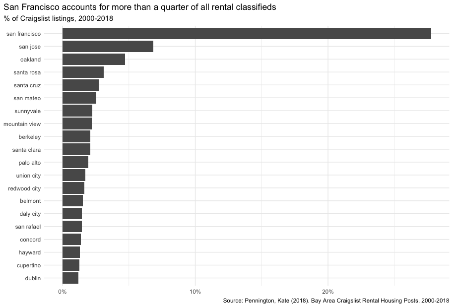

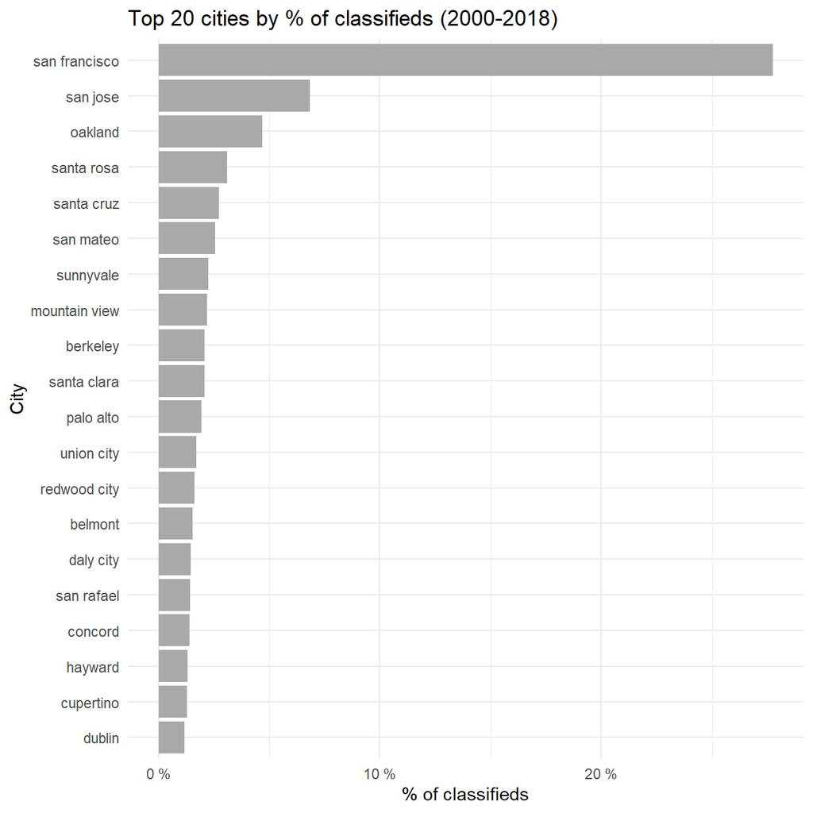

```r
listings <- rent %>%
  group_by(city) %>%
  summarise(count = n()) %>%
  ungroup() %>%
  mutate(percentage = count / sum(count) * 100) %>%
  arrange(desc(percentage)) %>%
  slice_head(n = 20)

ggplot(listings, aes(
    x = reorder(city, percentage),
    y = percentage
  )) +
  geom_col(fill = "darkgrey") +
#  geom_text(
#    aes(label = sprintf("%.1f%%", percentage)),
#    hjust = -0.1,
#    size = 3
#  ) +
  coord_flip() +
  scale_y_continuous(
        labels = label_number(suffix = " %")
        # alternative: label_percent(), but already multiplied by 100 above
    ) +
  theme_minimal() +
  labs(
    title = "Top 20 cities by % of classifieds (2000-2018)",
    x = "City", # y-axis after flip
    y = "% of classifieds" # x-axis after flip
  )
```

Make a plot that shows the evolution of median prices in San Francisco for 0, 1, 2, and 3 bedrooms listings. The final graph should look like this

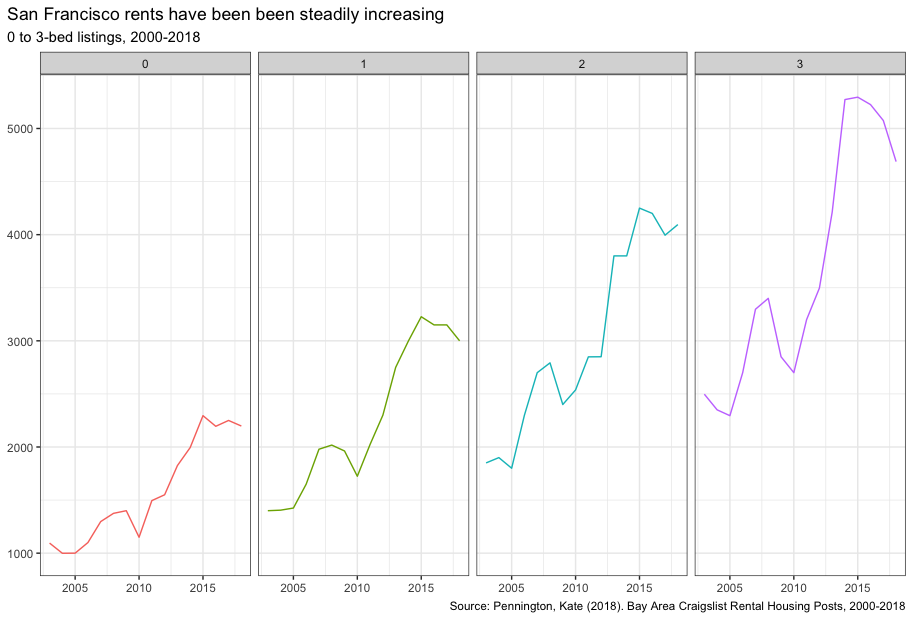

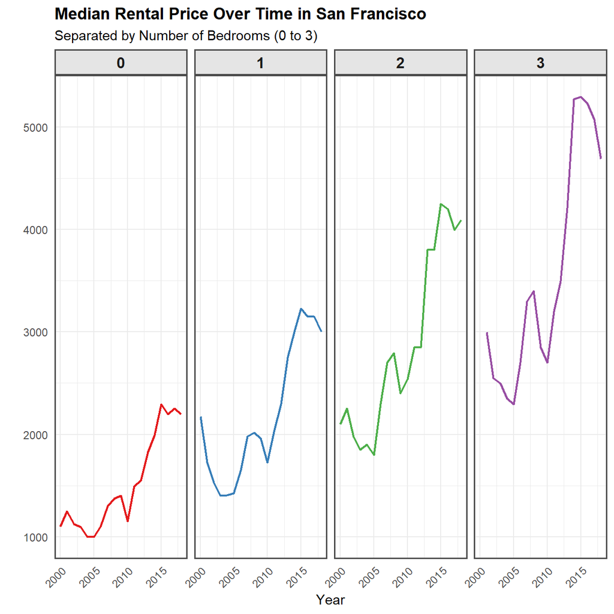

```r
sf_median_rent_sanFrancisco <- rent %>%
  filter(city == "san francisco") %>%
  mutate(beds = factor(beds)) %>%
  filter(beds %in% c("0", "1", "2", "3")) %>%

  group_by(year, beds) %>%
  summarise(
    median_price = median(price, na.rm = TRUE),
    .groups = 'drop'
  )

ggplot(sf_median_rent_sanFrancisco, aes(
    x = year,
    y = median_price,
    group = beds,
    color = beds
  )) +

  geom_line(linewidth = 0.8) +
#  geom_point(size = 1.5) +
  scale_color_brewer(palette = "Set1") +

  facet_wrap(~ beds, ncol = 4) +

  theme_minimal() +
  labs(
    title = "Median Rental Price Over Time in San Francisco",
    subtitle = "Separated by Number of Bedrooms (0 to 3)",
    x = "Year",
    y = ""
  ) +
  theme(
    plot.title = element_text(face = "bold"),
    strip.text = element_text(size = 12, face = "bold"),
    axis.text.x = element_text(angle = 45, hjust = 1),
    panel.border = element_rect(color = "gray30", fill = NA, linewidth = 1),
    strip.background = element_rect(fill = "gray90", color = "gray30", linewidth = 1),
    legend.position = "none"
  )
```

Finally, make a plot that shows median rental prices for the top 12 cities in the Bay area. Your final graph should look like this

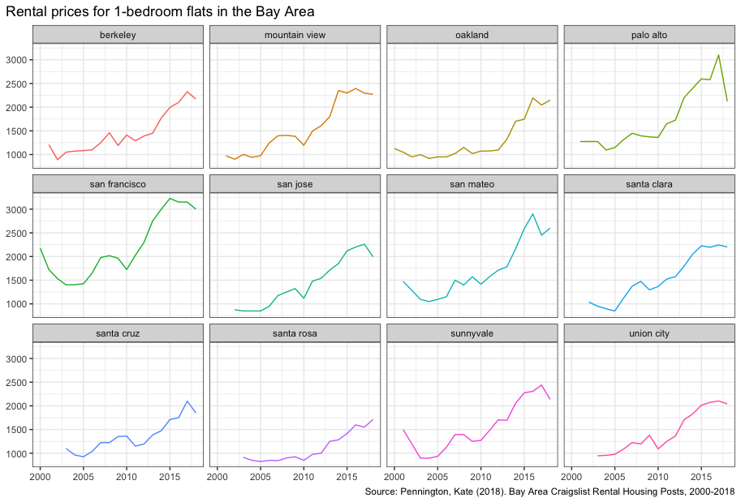

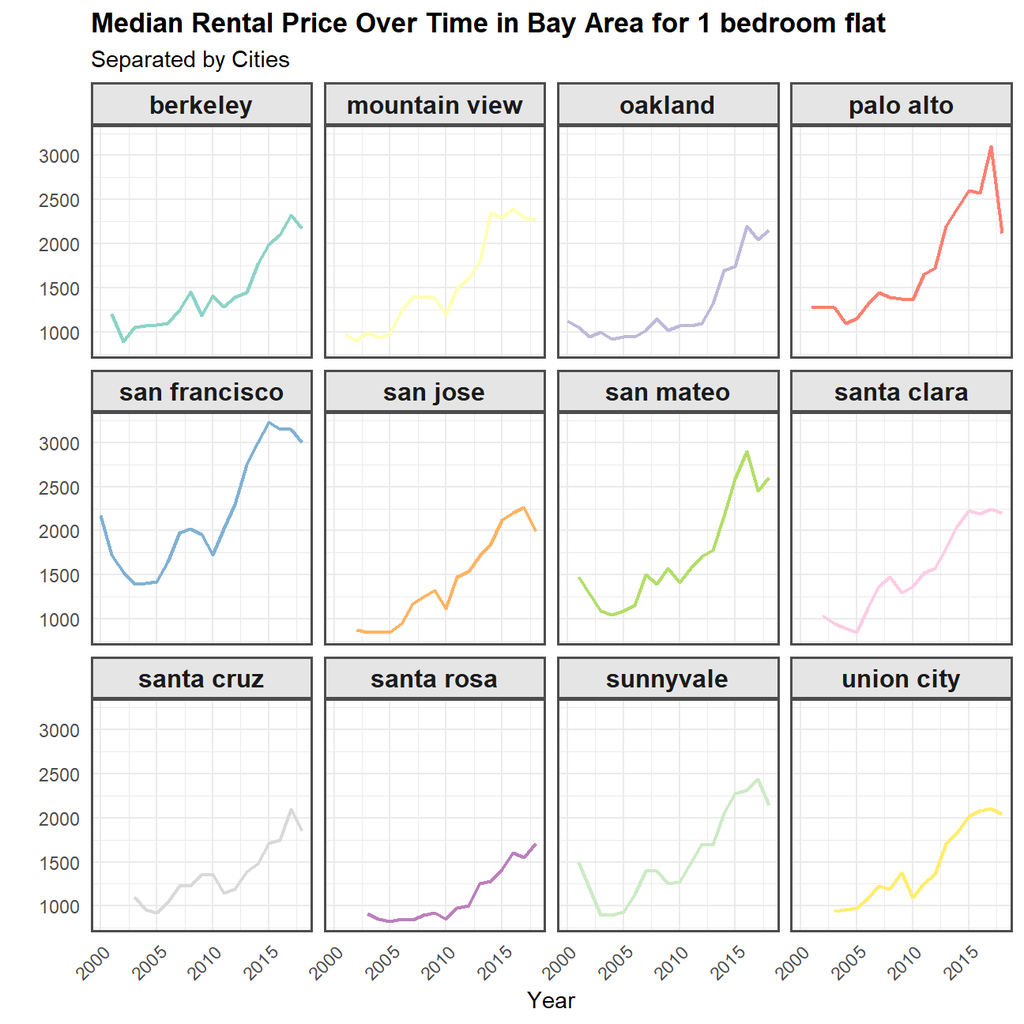

```r
top_12_cities <- rent %>%
  count(city, sort = TRUE) %>%
  slice_head(n = 12) %>%
  pull(city) # Extract the vector of top 12 city names

sf_median_rent <- rent %>%
  filter(beds == 1) %>%
  filter(city %in% top_12_cities) %>%

  group_by(year, city) %>%
  summarise(
    median_price = median(price, na.rm = TRUE),
    .groups = 'drop'
  )

ggplot(sf_median_rent, aes(
    x = year,
    y = median_price,
    group = city,
    color = city
  )) +

  geom_line(linewidth = 0.8) +
#  geom_point(size = 1.5) +
  scale_color_brewer(palette = "Set3") +

  facet_wrap(~ city) +

  theme_minimal() +
  labs(
    title = "Median Rental Price Over Time in Bay Area for 1 bedroom flat",
    subtitle = "Separated by Cities",
    x = "Year",
    y = ""
  ) +
  theme(
    plot.title = element_text(face = "bold"),
    strip.text = element_text(size = 12, face = "bold"),
    axis.text.x = element_text(angle = 45, hjust = 1),
    panel.border = element_rect(color = "gray30", fill = NA, linewidth = 1),
    strip.background = element_rect(fill = "gray90", color = "gray30", linewidth = 1),
    legend.position = "none"
  )
```

What can you infer from these plots? Don’t just explain what’s in the graph, but speculate or tell a short story (1-2 paragraphs max).

First of all, San Francisco has the most listings, that’s clear, no dangerous rivals. Next to that, it is easy to observe that in a certain amount (0-3), the more rooms you have, the bigger increase can be measured over the year on the price. Also, there are some expensive cities - few can be compared to San Francisco.

Does this mean San Francisco has a bright future? Regarding the real estate sector, probably yes. However, this means strong separation between social classes, mainly caused only by the price. The average rental price for only one bedroom flat is around 3k USD, which is a lot. This means that only wealthy people can afford to live there, and the rest will be pushed out to the suburbs or other cities. This leads not only to different communities in that area, but it will change the local businesses as well. Only a few McDonald’s will be operating in a city that can not provide the necessary workers for it. Interesting, how one factor can change the whole social structure of a city.

# 4 Hollywood Age Gap

The website https://hollywoodagegap.com is a record of *THE AGE DIFFERENCE IN YEARS BETWEEN MOVIE LOVE INTERESTS*. This is an informational site showing the age gap between movie love interests and the data follows certain rules:

- The two (or more) actors play actual love interests (not just friends, coworkers, or some other non-romantic type of relationship)
- The youngest of the two actors is at least 17 years old
- No animated characters

The age gaps dataset includes “gender” columns, which always contain the values “man” or “woman”. These values appear to indicate how the characters in each film identify and some of these values do not match how the actor identifies. We apologize if any characters are misgendered in the data!

The following is a data dictionary of the variables used

| variable | class | description |
| --- | --- | --- |
| movie_name | character | Name of the film |
| release_year | integer | Release year |
| director | character | Director of the film |
| age_difference | integer | Age difference between the characters in whole years |
| couple_number | integer | An identifier for the couple in case multiple couples are listed for this film |
| actor_1_name | character | The name of the older actor in this couple |
| actor_2_name | character | The name of the younger actor in this couple |
| character_1_gender | character | The gender of the older character, as identified by the person who submitted the data for this couple |
| character_2_gender | character | The gender of the younger character, as identified by the person who submitted the data for this couple |
| actor_1_birthdate | date | The birthdate of the older member of the couple |
| actor_2_birthdate | date | The birthdate of the younger member of the couple |
| actor_1_age | integer | The age of the older actor when the film was released |
| actor_2_age | integer | The age of the younger actor when the film was released |

```r
age_gaps <- readr::read_csv('https://raw.githubusercontent.com/rfordatascience/tidytuesday/master/data/2023/2023-02-14/age_gaps.csv')
skimr::skim(age_gaps)
```

Data summary

| Name | age_gaps |
| --- | --- |
| Number of rows | 1155 |
| Number of columns | 13 |
| _______________________ |  |
| Column type frequency: |  |
| character | 6 |
| Date | 2 |
| numeric | 5 |
| ________________________ |  |
| Group variables | None |

**Variable type: character**

| skim_variable | n_missing | complete_rate | min | max | empty | n_unique | whitespace |
| --- | --- | --- | --- | --- | --- | --- | --- |
| movie_name | 0 | 1 | 2 | 43 | 0 | 830 | 0 |
| director | 0 | 1 | 3 | 31 | 0 | 510 | 0 |
| actor_1_name | 0 | 1 | 6 | 22 | 0 | 567 | 0 |
| actor_2_name | 0 | 1 | 7 | 27 | 0 | 647 | 0 |
| character_1_gender | 0 | 1 | 3 | 5 | 0 | 2 | 0 |
| character_2_gender | 0 | 1 | 3 | 5 | 0 | 2 | 0 |

**Variable type: Date**

| skim_variable | n_missing | complete_rate | min | max | median | n_unique |
| --- | --- | --- | --- | --- | --- | --- |
| actor_1_birthdate | 0 | 1 | 1889-04-16 | 1996-06-01 | 1964-10-03 | 562 |
| actor_2_birthdate | 0 | 1 | 1906-10-06 | 1996-11-11 | 1974-07-30 | 640 |

**Variable type: numeric**

| skim_variable | n_missing | complete_rate | mean | sd | p0 | p25 | p50 | p75 | p100 | hist |
| --- | --- | --- | --- | --- | --- | --- | --- | --- | --- | --- |
| release_year | 0 | 1 | 2000.8 | 16.37 | 1935 | 1997 | 2004 | 2012 | 2022 | ▁▁▁▆▇ |
| age_difference | 0 | 1 | 10.4 | 8.51 | 0 | 4 | 8 | 15 | 52 | ▇▃▂▁▁ |
| couple_number | 0 | 1 | 1.4 | 0.75 | 1 | 1 | 1 | 2 | 7 | ▇▁▁▁▁ |
| actor_1_age | 0 | 1 | 40.6 | 10.42 | 18 | 33 | 39 | 47 | 81 | ▂▇▅▂▁ |
| actor_2_age | 0 | 1 | 30.2 | 7.50 | 17 | 25 | 29 | 34 | 68 | ▇▇▂▁▁ |

```r
glimpse(age_gaps)
```

```
## Rows: 1,155
## Columns: 13
## $ movie_name         <chr> "Harold and Maude", "Venus", "The Quiet American", …
## $ release_year       <dbl> 1971, 2006, 2002, 1998, 2010, 1992, 2009, 1999, 199…
## $ director           <chr> "Hal Ashby", "Roger Michell", "Phillip Noyce", "Joe…
## $ age_difference     <dbl> 52, 50, 49, 45, 43, 42, 40, 39, 38, 38, 36, 36, 35,…
## $ couple_number      <dbl> 1, 1, 1, 1, 1, 1, 1, 1, 1, 1, 1, 1, 1, 1, 1, 1, 1, …
## $ actor_1_name       <chr> "Ruth Gordon", "Peter O'Toole", "Michael Caine", "D…
## $ actor_2_name       <chr> "Bud Cort", "Jodie Whittaker", "Do Thi Hai Yen", "T…
## $ character_1_gender <chr> "woman", "man", "man", "man", "man", "man", "man", …
## $ character_2_gender <chr> "man", "woman", "woman", "woman", "man", "woman", "…
## $ actor_1_birthdate  <date> 1896-10-30, 1932-08-02, 1933-03-14, 1930-09-17, 19…
## $ actor_2_birthdate  <date> 1948-03-29, 1982-06-03, 1982-10-01, 1975-11-08, 19…
## $ actor_1_age        <dbl> 75, 74, 69, 68, 81, 59, 62, 69, 57, 77, 59, 56, 65,…
## $ actor_2_age        <dbl> 23, 24, 20, 23, 38, 17, 22, 30, 19, 39, 23, 20, 30,…
```

```r
head(age_gaps)
```

```
## # A tibble: 6 × 13
##   movie_name     release_year director age_difference couple_number actor_1_name
##   <chr>                 <dbl> <chr>             <dbl>         <dbl> <chr>
## 1 Harold and Ma…         1971 Hal Ash…             52             1 Ruth Gordon
## 2 Venus                  2006 Roger M…             50             1 Peter O'Too…
## 3 The Quiet Ame…         2002 Phillip…             49             1 Michael Cai…
## 4 The Big Lebow…         1998 Joel Co…             45             1 David Huddl…
## 5 Beginners              2010 Mike Mi…             43             1 Christopher…
## 6 Poison Ivy             1992 Katt Sh…             42             1 Tom Skerritt
## # ℹ 7 more variables: actor_2_name <chr>, character_1_gender <chr>,
## #   character_2_gender <chr>, actor_1_birthdate <date>,
## #   actor_2_birthdate <date>, actor_1_age <dbl>, actor_2_age <dbl>
```

How would you explore this data set? Here are some ideas of tables/ graphs to help you with your analysis

- How is `age_difference` distributed? What’s the ‘typical’ `age_difference` in movies?

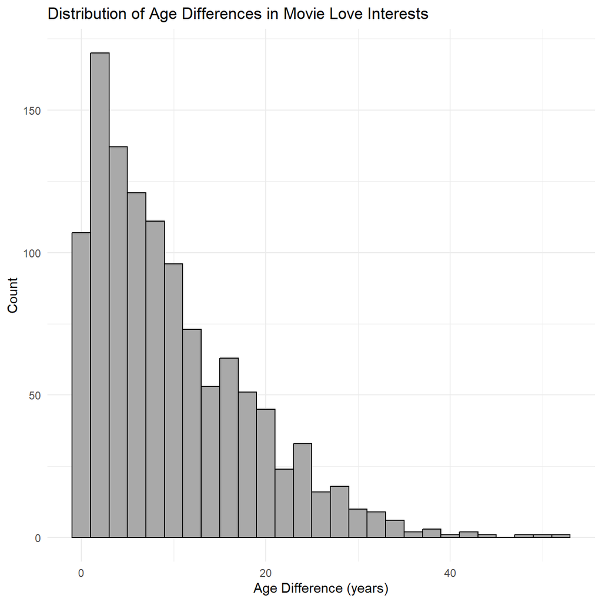

```r
ggplot(age_gaps, aes(x = age_difference)) +
  geom_histogram(binwidth = 2, fill = "darkgrey", color = "black") +
  theme_minimal() +
  labs(
    title = "Distribution of Age Differences in Movie Love Interests",
    x = "Age Difference (years)",
    y = "Count"
  )
```

Seems like the distribution is right-skewed, peaking at 2-3 years of difference between the actors. There are a lot of movies with romantic relationships with over 10 years of age gap.

- The `half plus seven\` rule. Large age disparities in relationships carry certain stigmas. One popular rule of thumb is the [half-your-age-plus-seven](https://en.wikipedia.org/wiki/Age_disparity_in_sexual_relationships#The_.22half-your-age-plus-seven.22_rule) rule. This rule states you should never date anyone under half your age plus seven, establishing a minimum boundary on whom one can date. In order for a dating relationship to be acceptable under this rule, your partner’s age must be:

$$\frac{\text{Your age}}{2} + 7 <
\text{Partner Age} < (\text{Your age} - 7) * 2$$
How frequently does this rule apply in this dataset?

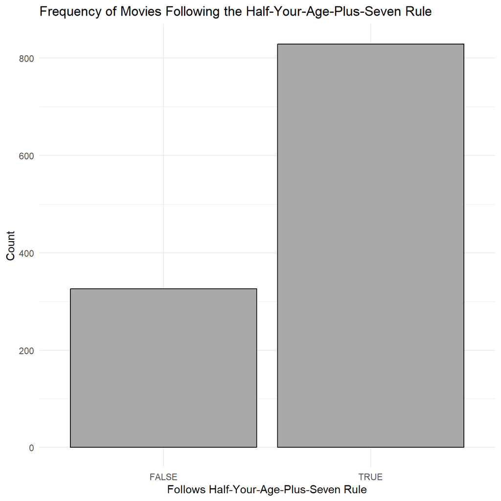

```r
age_gaps <- age_gaps %>%
  mutate(
    half_plus_seven_lower = (actor_1_age / 2) + 7,
    half_plus_seven_upper = (actor_1_age - 7) * 2,
    follows_half_plus_seven = actor_2_age >= half_plus_seven_lower & actor_2_age <= half_plus_seven_upper
  )

ggplot(age_gaps, aes(x = follows_half_plus_seven)) +
  geom_bar(fill = "darkgrey", color = "black") +
  theme_minimal() +
  labs(
    title = "Frequency of Movies Following the Half-Your-Age-Plus-Seven Rule",
    x = "Follows Half-Your-Age-Plus-Seven Rule",
    y = "Count"
  )
```

- Which movie has the greatest number of love interests?

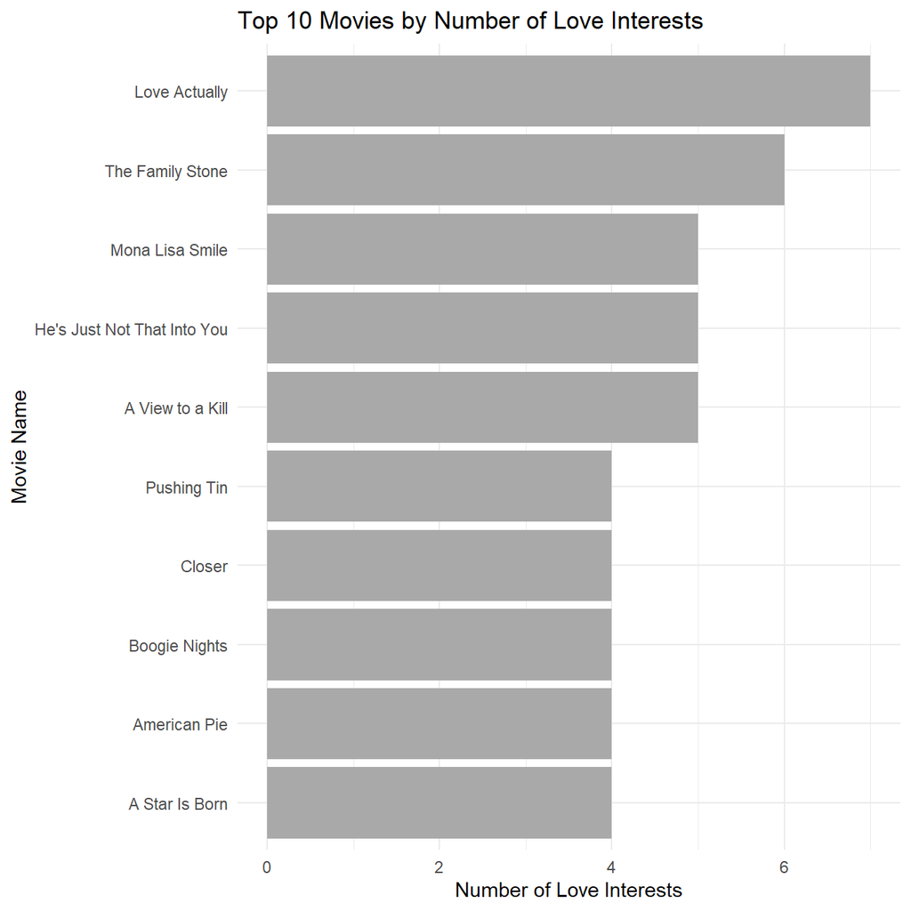

```r
top_movies <- age_gaps %>%
  group_by(movie_name) %>%
  summarise(love_interest_count = n()) %>%
  arrange(desc(love_interest_count)) %>%
  slice_head(n = 10)
ggplot(top_movies, aes(x = reorder(movie_name, love_interest_count), y = love_interest_count)) +
  geom_col(fill = "darkgrey") +
  coord_flip() +
  theme_minimal() +
  labs(
    title = "Top 10 Movies by Number of Love Interests",
    x = "Movie Name",
    y = "Number of Love Interests"
  )
```

- Which actors/ actresses have the greatest number of love interests in this dataset?

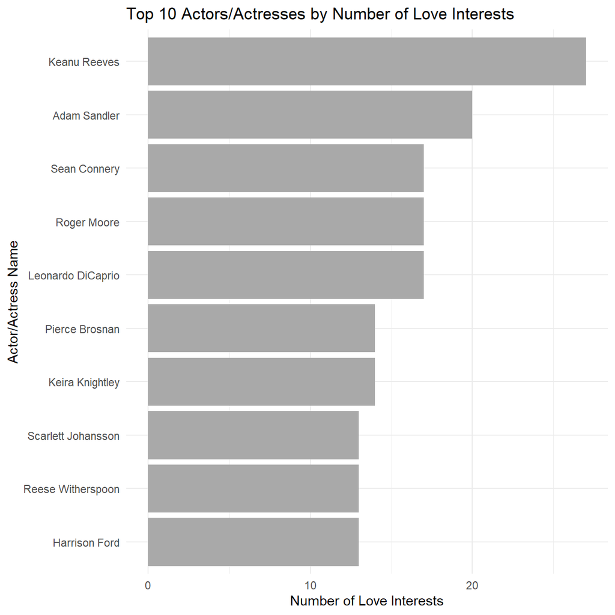

```r
top_actors <- age_gaps %>%
  pivot_longer(cols = c(actor_1_name, actor_2_name), names_to = "actor_role", values_to = "actor_name") %>%
  group_by(actor_name) %>%
  summarise(love_interest_count = n()) %>%
  arrange(desc(love_interest_count)) %>%
  slice_head(n = 10)

ggplot(top_actors, aes(x = reorder(actor_name, love_interest_count), y = love_interest_count)) +
  geom_col(fill = "darkgrey") +
  coord_flip() +
  theme_minimal() +
  labs(
    title = "Top 10 Actors/Actresses by Number of Love Interests",
    x = "Actor/Actress Name",
    y = "Number of Love Interests"
  )
```

- Is the mean/median age difference staying constant over the years (1935 - 2022)?

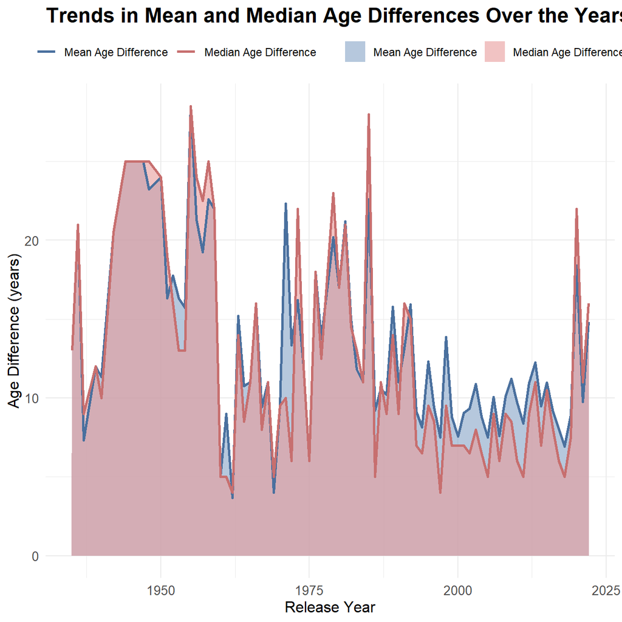

```r
age_trends <- age_gaps %>%
  group_by(release_year) %>%
  summarise(
    mean_age_difference = mean(age_difference, na.rm = TRUE),
    median_age_difference = median(age_difference, na.rm = TRUE)
)

age_trends_long <- age_trends %>%
  pivot_longer(
    cols = c(mean_age_difference, median_age_difference),
    names_to = "statistic_type",
    values_to = "age_difference"
  )

ggplot(age_trends_long, aes(x = release_year, y = age_difference, fill = statistic_type)) +
  geom_area(alpha = 0.6, position = "identity") +
  geom_line(aes(color = statistic_type), linewidth = 0.9) +

  theme_minimal() +
  labs(
    title = "Trends in Mean and Median Age Differences Over the Years",
    x = "Release Year",
    y = "Age Difference (years)",
    fill = "Statistic"
  ) +

  scale_fill_manual(
    values = c(
      "mean_age_difference" = "#85A3C7", # Softer blue
      "median_age_difference" = "#E89B9B" # Softer red/rose
    ),
    labels = c("Mean Age Difference", "Median Age Difference")
  ) +
  scale_color_manual( # Use slightly darker versions for the lines to stand out
    values = c(
      "mean_age_difference" = "#4A709E", # Darker shade of the blue
      "median_age_difference" = "#C76F6F" # Darker shade of the red/rose
    ),
    labels = c("Mean Age Difference", "Median Age Difference")
  ) +

  theme(
    legend.title = element_blank(),
    legend.position = "top",
    plot.title = element_text(face = "bold", size = 16),
    axis.title = element_text(size = 12),
    axis.text = element_text(size = 10)
  )
```

No, it is reduced strongly over the years with only a few outliars

- How frequently does Hollywood depict same-gender love interests?

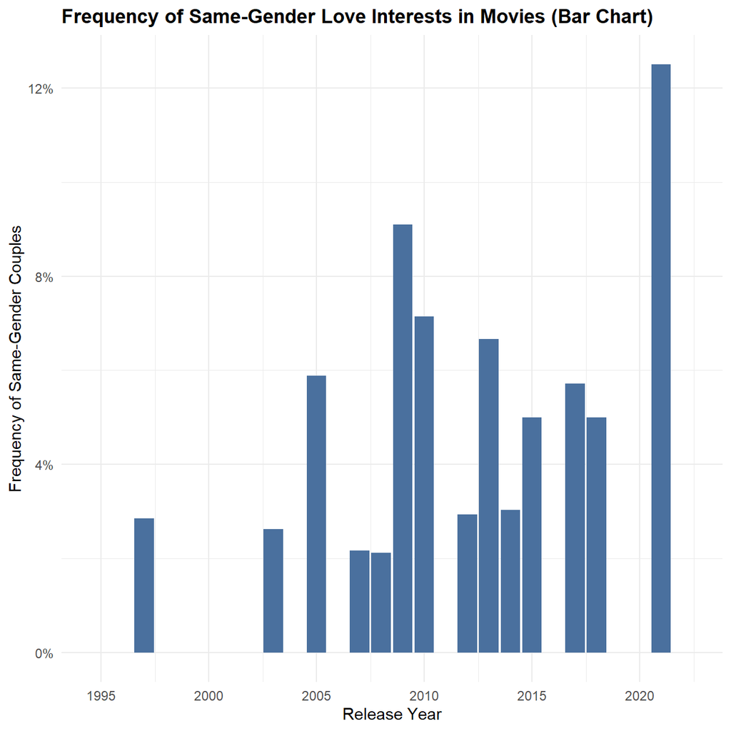

```r
same_gender_trends <- age_gaps %>%
  mutate(is_same_gender = (character_1_gender == character_2_gender)) %>%
  filter(release_year >= 1995) %>%

  group_by(release_year) %>%

  summarise(
    same_gender_count = sum(is_same_gender, na.rm = TRUE),
    total_couples = n(),
    .groups = 'drop'
    ) %>%

  mutate(
    same_gender_frequency = same_gender_count / total_couples
  )

ggplot(same_gender_trends, aes(x = release_year, y = same_gender_frequency)) +
  geom_col(fill = "#4A709E") +

  scale_y_continuous(labels = label_percent()) +
  scale_x_continuous(
    breaks = seq(1995, max(same_gender_trends$release_year, na.rm = TRUE), by = 5)
  ) +

  theme_minimal() +
  labs(
    title = "Frequency of Same-Gender Love Interests in Movies (Bar Chart)",
    x = "Release Year",
    y = "Frequency of Same-Gender Couples"
  ) +
  theme(
    plot.title = element_text(face = "bold"),
  )
```

# 5 Challenge 1: Replicating a chart

The purpose of this exercise is to reproduce a plot using your `dplyr` and `ggplot2` skills. It builds on exercise 1, the San Francisco rentals data.

You have to create a graph that calculates the cumulative % change in median rental prices for 0-, 1-, and 2-bed flats between 2000 and 2018 for the top twelve cities in Bay Area, by number of ads that appeared in Craigslist. Your final graph should look like below. You may find `dplyr::first()` a useful function

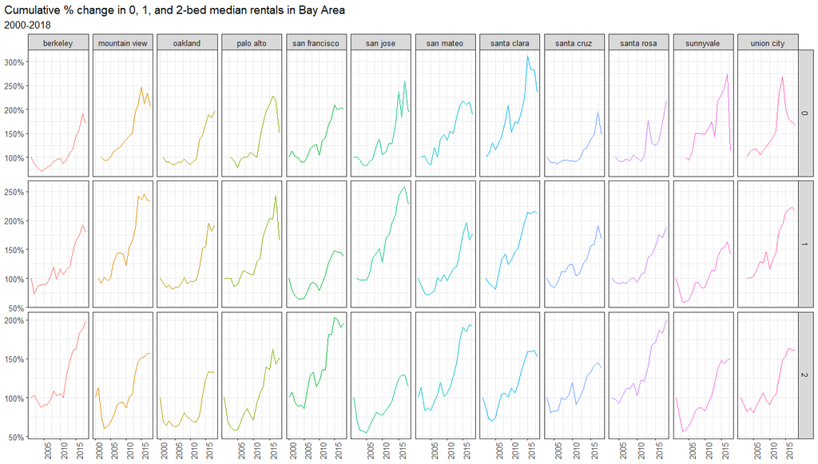

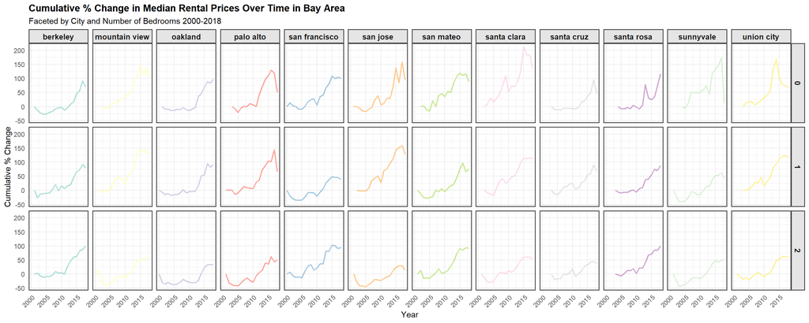

```r
top_12_cities <- rent %>%
  count(city, sort = TRUE) %>%
  slice_head(n = 12) %>%
  pull(city)

sf_median_rent <- rent %>%
  filter(beds %in% c(0, 1, 2)) %>%
  filter(city %in% top_12_cities) %>%
  group_by(year, city, beds) %>%
  summarise(
    median_price = median(price, na.rm = TRUE),
    .groups = 'drop'
  ) %>%
  group_by(city, beds) %>%
  arrange(year) %>%
  mutate(
    base_price = first(median_price),
    pct_change = (median_price - base_price) / base_price * 100
  ) %>%
  ungroup()

ggplot(sf_median_rent, aes(x = year, y = pct_change,
                           group = interaction(city, beds),
                           color = city
                           )) +
  geom_line(linewidth = 0.8, alpha = 0.7) +
  scale_color_brewer(palette = "Set3") +
  facet_grid(beds ~ city) +
  theme_minimal() +
  labs(
    title = "Cumulative % Change in Median Rental Prices Over Time in Bay Area",
    subtitle = "Faceted by City and Number of Bedrooms 2000-2018",
    x = "Year",
    y = "Cumulative % Change"
    ) +
  theme(
    plot.title = element_text(face = "bold"),
    strip.text = element_text(size = 10, face = "bold"),
    axis.text.x = element_text(angle = 45, hjust = 1),
    panel.border = element_rect(color = "gray30", fill = NA, linewidth = 1),
    strip.background = element_rect(fill = "gray90", color = "gray30", linewidth = 1),
    legend.position = "none"
  )
```

Deliverable - a knitted HTML, displaying code and output.